# Part II - (Prosper Loan Data Explanatory Analysis)

## by (James Gabriel)

## Investigation Overview

The main purpose of this exploration was to figure out the demography of borrowers like (state, occupation, employment status) and check for pointers to the loan amount that was granted to borrowers, what determined the amount borrowers could get, if there was any relationship between other variables and the loan amount.

Can borrowers monthly salary influence loan amount, does the fact that the borrower is a homeowner affect loan amount, etc.

## Dataset Overview

The dataset that was explored contained information about over 100,000 loan listings and their characteristics. Variables include listing category to signify why the loan was taken, credit scores, employment status, occupation, investors to show how many investors contributed to a particular loan and other interesting variables.

## (Visualization 1) - Borrowers Demography

For the first visualization, we would look at the demography of borrowers to get a general knowledge of the type of people who take out loans. We would show their state and occupation, and limit to the top 10. These 2 categories should be enough to give us an overview of the borrowers.

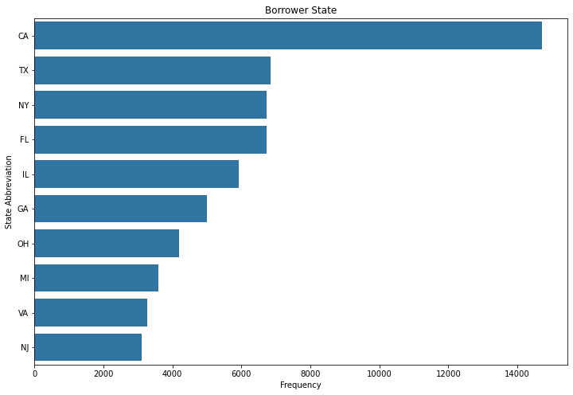

As we saw in the previous slide, most borrowers are from California, Texas and New york. Next we would limit the plot categories to 10 to see that Professionals and Computer Programmers are the occupations that take the most loans.

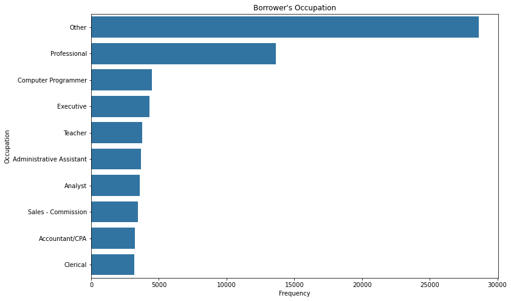

## (Visualization 2)

Now that we have a general idea of the population of the borrowers, let's further show their employment status and income range to gain further insight into the finances of people taking loans.

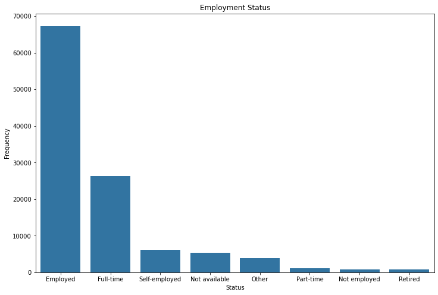

Most of the borrowers population are employed or have a full time job. Unlike initial impression, because most of the loans were taken for business, self-employed people do not top the list. People between the 25k-75k income range take the most loans as we can see in the plot below.

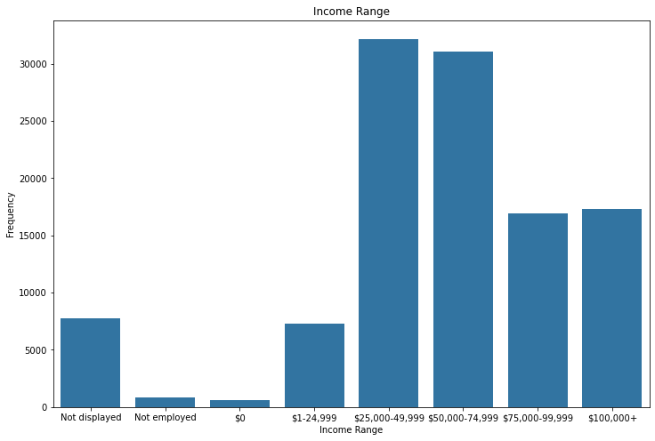

## (Visualization 3)

Finally we'd show how the higher your income the higher your chances of getting larger loans as is obvious in the violin plot below. The higher the income, the wider the width of the violin plot in top areas that signifies higher loan amounts.

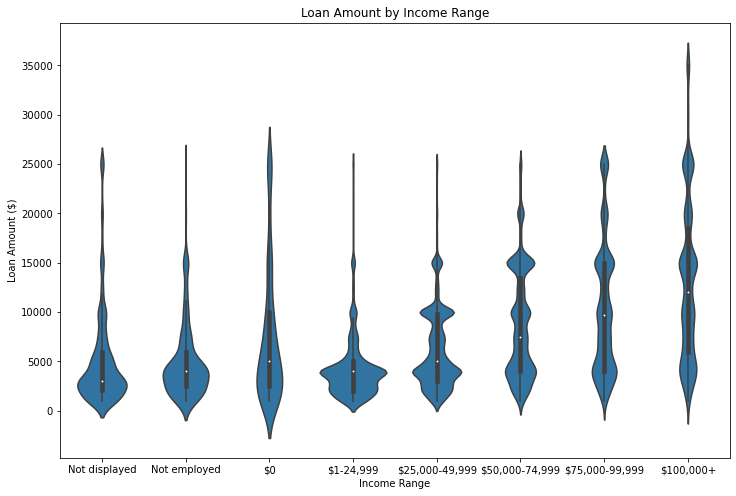

Also, the more the income the more likelihood it is that the borrower is a homeowner. The population below the 50k income range, have lesser homeowners than renters.

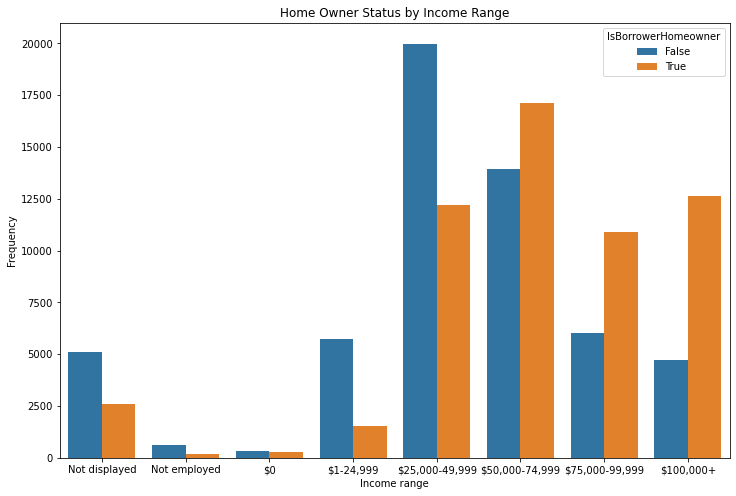